# Task To Be Performed

Load the transaction dataset below into an analysis tool of your choice (Excel, R, SAS, Tableau, or similar)

Start by doing some basic checks – are there any data issues? Does the data need to be cleaned?

Gather some interesting overall insights about the data. For example -- what is the average transaction amount? How many transactions do customers make each month, on average?

Segment the dataset by transaction date and time. Visualise transaction volume and spending over the course of an average day or week. Consider the effect of any outliers that may distort your analysis.

For a challenge – what insights can you draw from the location information provided in the dataset?

# Loading the Dependencies

```python
import pandas as pd
import numpy as np
import seaborn as sns
import matplotlib.pyplot as plt
from matplotlib import rcParams
import plotly.express as px
%matplotlib inline
import plotly.offline as py
py.init_notebook_mode(connected=True)
import plotly.graph_objs as go
import plotly.tools as tls
from bs4 import BeautifulSoup
```

```python
#Loading the dataset
data=pd.read_excel("C:/Users/Rahul Gupta/Documents/Dataset/ANZ synthesised transaction dataset.xlsx")
data.head()
```

|  | status | card_present_flag | bpay_biller_code | account | currency | long_lat | txn_description | merchant_id | merchant_code | first_name | ... | age | merchant_suburb | merchant_state | extraction | amount | transaction_id | country | customer_id | merchant_long_lat | movement |
| --- | --- | --- | --- | --- | --- | --- | --- | --- | --- | --- | --- | --- | --- | --- | --- | --- | --- | --- | --- | --- | --- |
| 0 | authorized | 1.0 | NaN | ACC-1598451071 | AUD | 153.41 -27.95 | POS | 81c48296-73be-44a7-befa-d053f48ce7cd | NaN | Diana | ... | 26 | Ashmore | QLD | 2018-08-01T01:01:15.000+0000 | 16.25 | a623070bfead4541a6b0fff8a09e706c | Australia | CUS-2487424745 | 153.38 -27.99 | debit |
| 1 | authorized | 0.0 | NaN | ACC-1598451071 | AUD | 153.41 -27.95 | SALES-POS | 830a451c-316e-4a6a-bf25-e37caedca49e | NaN | Diana | ... | 26 | Sydney | NSW | 2018-08-01T01:13:45.000+0000 | 14.19 | 13270a2a902145da9db4c951e04b51b9 | Australia | CUS-2487424745 | 151.21 -33.87 | debit |
| 2 | authorized | 1.0 | NaN | ACC-1222300524 | AUD | 151.23 -33.94 | POS | 835c231d-8cdf-4e96-859d-e9d571760cf0 | NaN | Michael | ... | 38 | Sydney | NSW | 2018-08-01T01:26:15.000+0000 | 6.42 | feb79e7ecd7048a5a36ec889d1a94270 | Australia | CUS-2142601169 | 151.21 -33.87 | debit |
| 3 | authorized | 1.0 | NaN | ACC-1037050564 | AUD | 153.10 -27.66 | SALES-POS | 48514682-c78a-4a88-b0da-2d6302e64673 | NaN | Rhonda | ... | 40 | Buderim | QLD | 2018-08-01T01:38:45.000+0000 | 40.90 | 2698170da3704fd981b15e64a006079e | Australia | CUS-1614226872 | 153.05 -26.68 | debit |
| 4 | authorized | 1.0 | NaN | ACC-1598451071 | AUD | 153.41 -27.95 | SALES-POS | b4e02c10-0852-4273-b8fd-7b3395e32eb0 | NaN | Diana | ... | 26 | Mermaid Beach | QLD | 2018-08-01T01:51:15.000+0000 | 3.25 | 329adf79878c4cf0aeb4188b4691c266 | Australia | CUS-2487424745 | 153.44 -28.06 | debit |

5 rows × 23 columns

```python
data.columns
```

```
Index(['status', 'card_present_flag', 'bpay_biller_code', 'account',
       'currency', 'long_lat', 'txn_description', 'merchant_id',
       'merchant_code', 'first_name', 'balance', 'date', 'gender', 'age',
       'merchant_suburb', 'merchant_state', 'extraction', 'amount',
       'transaction_id', 'country', 'customer_id', 'merchant_long_lat',
       'movement'],
      dtype='object')
```

```python
data.shape
```

```
(12043, 23)
```

```python
data.info()
```

```
<class 'pandas.core.frame.DataFrame'>
RangeIndex: 12043 entries, 0 to 12042
Data columns (total 23 columns):
 #   Column             Non-Null Count  Dtype
---  ------             --------------  -----
 0   status             12043 non-null  object
 1   card_present_flag  7717 non-null   float64
 2   bpay_biller_code   885 non-null    object
 3   account            12043 non-null  object
 4   currency           12043 non-null  object
 5   long_lat           12043 non-null  object
 6   txn_description    12043 non-null  object
 7   merchant_id        7717 non-null   object
 8   merchant_code      883 non-null    float64
 9   first_name         12043 non-null  object
 10  balance            12043 non-null  float64
 11  date               12043 non-null  datetime64[ns]
 12  gender             12043 non-null  object
 13  age                12043 non-null  int64
 14  merchant_suburb    7717 non-null   object
 15  merchant_state     7717 non-null   object
 16  extraction         12043 non-null  object
 17  amount             12043 non-null  float64
 18  transaction_id     12043 non-null  object
 19  country            12043 non-null  object
 20  customer_id        12043 non-null  object
 21  merchant_long_lat  7717 non-null   object
 22  movement           12043 non-null  object
dtypes: datetime64[ns](1), float64(4), int64(1), object(17)
memory usage: 2.1+ MB
```

```python
#Getting the summary of numerical variables
data.describe()
```

|  | card_present_flag | merchant_code | balance | age | amount |
| --- | --- | --- | --- | --- | --- |
| count | 7717.000000 | 883.0 | 12043.000000 | 12043.000000 | 12043.000000 |
| mean | 0.802644 | 0.0 | 14704.195553 | 30.582330 | 187.933588 |
| std | 0.398029 | 0.0 | 31503.722652 | 10.046343 | 592.599934 |
| min | 0.000000 | 0.0 | 0.240000 | 18.000000 | 0.100000 |
| 25% | 1.000000 | 0.0 | 3158.585000 | 22.000000 | 16.000000 |
| 50% | 1.000000 | 0.0 | 6432.010000 | 28.000000 | 29.000000 |
| 75% | 1.000000 | 0.0 | 12465.945000 | 38.000000 | 53.655000 |
| max | 1.000000 | 0.0 | 267128.520000 | 78.000000 | 8835.980000 |

```python
#Getting the summary of categorical variables
data.describe(include='O')
```

|  | status | bpay_biller_code | account | currency | long_lat | txn_description | merchant_id | first_name | gender | merchant_suburb | merchant_state | extraction | transaction_id | country | customer_id | merchant_long_lat | movement |
| --- | --- | --- | --- | --- | --- | --- | --- | --- | --- | --- | --- | --- | --- | --- | --- | --- | --- |
| count | 12043 | 885 | 12043 | 12043 | 12043 | 12043 | 7717 | 12043 | 12043 | 7717 | 7717 | 12043 | 12043 | 12043 | 12043 | 7717 | 12043 |
| unique | 2 | 3 | 100 | 1 | 100 | 6 | 5725 | 80 | 2 | 1609 | 8 | 9442 | 12043 | 1 | 100 | 2703 | 2 |
| top | authorized | 0 | ACC-1598451071 | AUD | 153.41 -27.95 | SALES-POS | 106e1272-44ab-4dcb-a438-dd98e0071e51 | Michael | M | Melbourne | NSW | 2018-09-03T11:00:00.000+0000 | 653c77a7ce9d4c1aa42bfafa81fa8153 | Australia | CUS-2487424745 | 151.21 -33.87 | debit |
| freq | 7717 | 883 | 578 | 12043 | 578 | 3934 | 14 | 746 | 6285 | 255 | 2169 | 10 | 1 | 12043 | 578 | 145 | 11160 |

# Explore the Data

```python
#Number of null values in each column
data.isna().sum()
```

```
status                   0
card_present_flag     4326
bpay_biller_code     11158
account                  0
currency                 0
long_lat                 0
txn_description          0
merchant_id           4326
merchant_code        11160
first_name               0
balance                  0
date                     0
gender                   0
age                      0
merchant_suburb       4326
merchant_state        4326
extraction               0
amount                   0
transaction_id           0
country                  0
customer_id              0
merchant_long_lat     4326
movement                 0
dtype: int64
```

```python
#Percentage of null values in each columns
data.isna().sum()/data.shape[0]
```

```
status               0.000000
card_present_flag    0.359213
bpay_biller_code     0.926513
account              0.000000
currency             0.000000
long_lat             0.000000
txn_description      0.000000
merchant_id          0.359213
merchant_code        0.926679
first_name           0.000000
balance              0.000000
date                 0.000000
gender               0.000000
age                  0.000000
merchant_suburb      0.359213
merchant_state       0.359213
extraction           0.000000
amount               0.000000
transaction_id       0.000000
country              0.000000
customer_id          0.000000
merchant_long_lat    0.359213
movement             0.000000
dtype: float64
```

```python
#Number of unique customers in the dataset
data['customer_id'].nunique()
```

```
100
```

```python
#Average Transaction Amount
Avg_tran_amt=data['amount'].sum()/data['amount'].count()
print("The average transaction amount is {}" .format(Avg_tran_amt))
```

```
The average transaction amount is 187.93358797641784
```

```python
#Number of transaction by month
month=data['date'].dt.month
pd.crosstab(index=month,columns='count')
```

| col_0 date | count |
| --- | --- |
| 8 | 3943 |
| 9 | 4013 |
| 10 | 4087 |

10th month of the year 2018 have maximum number of transaction.

```python
#Step for showing number of unique entities in each data columns:
data.nunique()
```

```
status                   2
card_present_flag        2
bpay_biller_code         3
account                100
currency                 1
long_lat               100
txn_description          6
merchant_id           5725
merchant_code            1
first_name              80
balance              12006
date                    91
gender                   2
age                     33
merchant_suburb       1609
merchant_state           8
extraction            9442
amount                4457
transaction_id       12043
country                  1
customer_id            100
merchant_long_lat     2703
movement                 2
dtype: int64
```

```python
#Dropping the unnecessary columns
df=data.drop(['merchant_code','country','currency'],axis=1)
```

```python
df["extraction"] = pd.to_datetime(df["extraction"])
# add a weekday column in dataset:
df['weekday'] = df['date'].dt.day_name()
```

```python
df.head()
```

[output not shown]

5 rows × 22 columns

```python
# By month:
mo_transactions = df.groupby(df['date'].dt.month).agg({'transaction_id': [('Number of transactions','count')],'amount':[('Total Amount','sum')]})
mo_transactions.columns = mo_transactions.columns.droplevel()
mo_transactions = mo_transactions.sort_values(by='Total Amount', ascending= False)
mo_transactions
```

| date | Number of transactions | Total Amount |
| --- | --- | --- |
| 10 | 4087 | 802798.47 |
| 9 | 4013 | 730550.21 |
| 8 | 3943 | 729935.52 |

- Maximum number of transactions are done in 10th month.
- Maximum transaction amount spent is also in 10th month.

```python
# By day:
no_transactions = df.groupby(df['date']).agg({'transaction_id': [('Number of transactions','count')],'amount':[('Total Amount','sum')]})
no_transactions.columns = no_transactions.columns.droplevel()
no_transactions = no_transactions.sort_values(by='Total Amount', ascending= False)
no_transactions
```

| date | Number of transactions | Total Amount |
| --- | --- | --- |
| 2018-10-15 | 112 | 51943.08 |
| 2018-10-19 | 158 | 51252.75 |
| 2018-09-14 | 161 | 48736.97 |
| 2018-08-20 | 97 | 48240.34 |
| 2018-10-26 | 157 | 46451.05 |
| 2018-08-06 | 99 | 42288.23 |
| 2018-09-17 | 112 | 42167.38 |
| 2018-08-17 | 172 | 41906.21 |
| 2018-09-26 | 149 | 41713.17 |
| 2018-10-01 | 103 | 40823.03 |
| 2018-09-03 | 109 | 40747.80 |
| 2018-10-12 | 154 | 40658.20 |
| 2018-10-29 | 102 | 38549.14 |
| 2018-09-07 | 152 | 38365.27 |
| 2018-10-05 | 168 | 38334.99 |
| 2018-09-20 | 146 | 38190.69 |
| 2018-08-03 | 157 | 38096.58 |
| 2018-09-28 | 174 | 37610.89 |
| 2018-10-22 | 112 | 36564.23 |
| 2018-09-24 | 101 | 36308.74 |
| 2018-08-31 | 153 | 36288.61 |
| 2018-10-24 | 148 | 35913.05 |
| 2018-09-06 | 152 | 35799.17 |
| 2018-08-07 | 114 | 35623.04 |
| 2018-08-15 | 144 | 34975.44 |
| 2018-10-18 | 150 | 34896.14 |
| 2018-08-23 | 152 | 34763.05 |
| 2018-09-12 | 149 | 34741.30 |
| 2018-08-24 | 156 | 34603.11 |
| 2018-09-21 | 160 | 33850.85 |

[output cut: 61 more lines]

```python
# By week:
no_transactions = df.groupby(['weekday']).agg({'transaction_id': [('Number of transactions','count')]})
no_transactions.columns = no_transactions.columns.droplevel()
no_transactions = no_transactions.sort_values(by='Number of transactions', ascending= False)
no_transactions
```

| weekday | Number of transactions |
| --- | --- |
| Friday | 2073 |
| Wednesday | 2063 |
| Thursday | 1801 |
| Saturday | 1709 |
| Sunday | 1550 |
| Tuesday | 1487 |
| Monday | 1360 |

[output not shown]

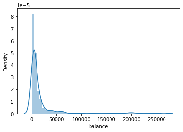

```python
sns.distplot(df['balance'])
```

- Distribution of balance is positively skewed.

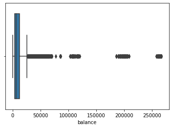

```python
sns.boxplot(x=df['balance'])
```

- Large number of outliers in balance column making the distribution highly skewed.

[output not shown]

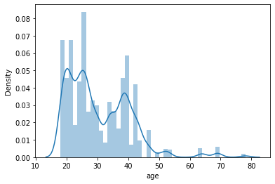

```python
sns.distplot(df['age'])
```

- Mean age is approximately 30

[output not shown]

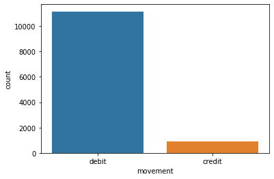

```python
sns.countplot(df['movement'])
```

- Large difference between debit and credit movement.
- Dataset is not balanced with respect to movement.